# **Project Fundamentals of AIML: Cardio Good Fitness Data Analysis**

**Marks: 40**

# **Submitted by: LARRY WEATHERFORD**

## **Context**

Cardio Good Fitness is a leading manufacturer of high-quality treadmills. The company offers three main products: the TM195, the TM498, and the TM798, which is their flagship product. With the rising demand for fitness in the market and an increasing number of competitors, Cardio Good Fitness wants to gain a better understanding of its existing customer profiles in order to develop more targeted marketing and product development strategies. They believe this will allow them to meet the needs and preferences of their customers, increase customer satisfaction, and drive revenue growth.

## **Objective**

In order to gain insights into its customer profiles, Cardio Good Fitness has collected demographic and product usage information for each of its customers. The dataset includes variables such as age, gender, income, and miles run on the treadmill for each of the three products.

Suppose you are hired as a Data Scientist in this company and the Data Science team has shared the data with you. The requirement is to analyze the data and identify patterns in product usage and the key characteristics of customers by conducting exploratory data analysis (EDA) to come up with customer profiles.

The goal is to answer key questions such as:

- What are the key characteristics of customers who purchase each product?
- How does product usage vary by each group?

## **Data Description**

The data is about customers of the treadmill product(s) of a retail store called Cardio Good Fitness. It contains the following variables-

- Product - The model no. of the treadmill
- Age - Age of the customer in no of years
- Gender - Gender of the customer
- Education - Education of the customer in no. of years
- Marital Status - Marital status of the customer
- Usage - Avg. number of times the customer wants to use the treadmill every week
- Fitness - Self rated fitness score of the customer (5 - very fit, 1 - very unfit)
- Income - Income of the customer
- Miles- Miles that a customer expects to run

### Let us start by importing the required libraries -

```python
# import libraries for data manipulation
import numpy as np
import pandas as pd

# import libraries for data visualization
import matplotlib.pyplot as plt
import seaborn as sns
%matplotlib inline
import plotly.express as px
```

### Understanding the structure of the data

```python
from google.colab import drive
drive.mount('/content/drive')
```

```python
# read the data
df = pd.read_csv("/content/drive/MyDrive/Projects/CardioGoodFitness.csv")
```

```python
# copying data to another variable to avoid any changes to original data
cardio = df.copy()
```

### Function Definition Section

```python
def my_countplot(df, column, xlabel, ylabel, title):
    #Define a function to build a countplot that will add % to the top of the bars

    ax = sns.countplot(x=column, data=df); #assign the plot to the variable ax

    # Add percentage labels to the top of each bar
    total = len(cardio["Product"])
    for p in ax.patches:
     percentage = '{:.1f}%'.format(100 * p.get_height()/total)
     x = p.get_x() + p.get_width() / 2 - 0.1
     y = p.get_y() + p.get_height()
     ax.annotate(percentage, (x, y), size=10)

   # set labels and title
    plt.xlabel(xlabel);
    plt.ylabel(ylabel);
    plt.title(title);

    # show plot
    plt.show();
```

```python
def set_labels(xlabel, ylabel, title):
    #Define a function to set the X & Y labels plus the Title to any plot

    # set labels and title
    plt.xlabel(xlabel);
    plt.ylabel(ylabel);
    plt.title(title);

    # show plot
    plt.show();
```

```python
def histbox(data, x, figsize=(10, 4)):
    # function to display 2 subplots (histplot & boxplot) side by side
    fig, axes = plt.subplots(1, 2, figsize=figsize)

    # Histplot
    ax_histplot = axes[0]  # Get the first subplot
    sns.set(style="whitegrid") #place a grid on this plot
    sns.histplot(data=data, x=x, kde=True, ax=ax_histplot)  # Create a histplot using the specified data and x-axis variable
    ax_histplot.set_title(f"Histplot for {x}")  # Set the title for the histplot

    # Boxplot
    ax_boxplot = axes[1]  # Get the second subplot
    sns.boxplot(data=data, x=x, ax=ax_boxplot, color='green')  # Create a boxplot using the specified data and x-axis variable
    ax_boxplot.set_title(f"Boxplot for {x}")  # Set the title for the boxplot

    plt.tight_layout()  # Adjust the spacing between subplots
    plt.show();  # Display the subplots
    sns.set(style="white") #change the plot background to white to remove the grid
```

```python
# returns the first 5 rows
cardio.head()
```

|  | Product | Age | Gender | Education | MaritalStatus | Usage | Fitness | Income | Miles |
| --- | --- | --- | --- | --- | --- | --- | --- | --- | --- |
| 0 | TM195 | 18 | Male | 14 | Single | 3 | 4 | 29562 | 112 |
| 1 | TM195 | 19 | Male | 15 | Single | 2 | 3 | 31836 | 75 |
| 2 | TM195 | 19 | Female | 14 | Partnered | 4 | 3 | 30699 | 66 |
| 3 | TM195 | 19 | Male | 12 | Single | 3 | 3 | 32973 | 85 |
| 4 | TM195 | 20 | Male | 13 | Partnered | 4 | 2 | 35247 | 47 |

**Observations:**

The DataFrame has 9 columns as mentioned in the Data Dictionary.

Data in each row corresponds to the product purchased by a customer.

### **Question 1:** How many rows and columns are present in the data? [0.5 mark]

```python
# use the shape attribute to assign variables (num_rows and num_cols) the count of rows and column count of the dataframe
num_rows, num_cols = cardio.shape

print("Number of rows: ", num_rows)
print("Number of columns: ", num_cols)
```

```
Number of rows:  180
Number of columns:  9
```

**Observations:**

The .shape attribute is used to show the data has 180 rows and 9 columns.

### **Question 2:** What are the datatypes of the different columns in the dataset? (The info() function can be used) [0.5 mark]

```python
cardio.info( )
```

```
<class 'pandas.core.frame.DataFrame'>
RangeIndex: 180 entries, 0 to 179
Data columns (total 9 columns):
 #   Column         Non-Null Count  Dtype
---  ------         --------------  -----
 0   Product        180 non-null    object
 1   Age            180 non-null    int64
 2   Gender         180 non-null    object
 3   Education      180 non-null    int64
 4   MaritalStatus  180 non-null    object
 5   Usage          180 non-null    int64
 6   Fitness        180 non-null    int64
 7   Income         180 non-null    int64
 8   Miles          180 non-null    int64
dtypes: int64(6), object(3)
memory usage: 12.8+ KB
```

**Observations**:

The info() method shows that the datatypes for each column is either an 'object' or 'int64'.

### **Question 3:** Write a code to convert the data type of the object type #variables to the 'categorical' type to reduce memory usage. [0.5 mark]

```python
# determine the 'object' datatype columns using select_dtypes().
# then use astype() to change the datatype to 'category' for each object type found.
object_columns = cardio.select_dtypes(['object']).columns
cardio[object_columns] = cardio[object_columns].astype('category')

#display the info() to show the datatypes have changed to 'category' and the memory usage is reduced from the previous info() results.
cardio.info()
```

```
<class 'pandas.core.frame.DataFrame'>
RangeIndex: 180 entries, 0 to 179
Data columns (total 9 columns):
 #   Column         Non-Null Count  Dtype
---  ------         --------------  -----
 0   Product        180 non-null    category
 1   Age            180 non-null    int64
 2   Gender         180 non-null    category
 3   Education      180 non-null    int64
 4   MaritalStatus  180 non-null    category
 5   Usage          180 non-null    int64
 6   Fitness        180 non-null    int64
 7   Income         180 non-null    int64
 8   Miles          180 non-null    int64
dtypes: category(3), int64(6)
memory usage: 9.5 KB
```

**Observations:**

The updated datatypes are now shown as 'category' for the Product, Gender, and MaritalStatus columns.

Notice the significant reduction of memory usage in the info() output after the 'object' datatypes are converted to 'category'. Memory was reduced from 12.8+ KB in Question 2 to 9.5 KB after Question 3 cardio.info() was excuted.

### **Question 4:** Are there any missing values in the data? If yes, treat them using an appropriate method. [0.5 mark]

```python
# use the method isnull().sum() to assign the number missing values in the data to a variable named missing_values_count
missing_values_count = df.isnull().sum()

print(missing_values_count)
```

```
Product          0
Age              0
Gender           0
Education        0
MaritalStatus    0
Usage            0
Fitness          0
Income           0
Miles            0
dtype: int64
```

**Observations:**

Using the isnull() method, we can see there are no missing values in any of the columns.

### **Question 5:** Check the statistical summary of the data. Which product type has had the highest number of sales? [1 marks]

```python
cardio.describe(include='all').T
```

|  | count | unique | top | freq | mean | std | min | 25% | 50% | 75% | max |
| --- | --- | --- | --- | --- | --- | --- | --- | --- | --- | --- | --- |
| Product | 180 | 3 | TM195 | 80 | NaN | NaN | NaN | NaN | NaN | NaN | NaN |
| Age | 180.0 | NaN | NaN | NaN | 28.788889 | 6.943498 | 18.0 | 24.0 | 26.0 | 33.0 | 50.0 |
| Gender | 180 | 2 | Male | 104 | NaN | NaN | NaN | NaN | NaN | NaN | NaN |
| Education | 180.0 | NaN | NaN | NaN | 15.572222 | 1.617055 | 12.0 | 14.0 | 16.0 | 16.0 | 21.0 |
| MaritalStatus | 180 | 2 | Partnered | 107 | NaN | NaN | NaN | NaN | NaN | NaN | NaN |
| Usage | 180.0 | NaN | NaN | NaN | 3.455556 | 1.084797 | 2.0 | 3.0 | 3.0 | 4.0 | 7.0 |
| Fitness | 180.0 | NaN | NaN | NaN | 3.311111 | 0.958869 | 1.0 | 3.0 | 3.0 | 4.0 | 5.0 |
| Income | 180.0 | NaN | NaN | NaN | 53719.577778 | 16506.684226 | 29562.0 | 44058.75 | 50596.5 | 58668.0 | 104581.0 |
| Miles | 180.0 | NaN | NaN | NaN | 103.194444 | 51.863605 | 21.0 | 66.0 | 94.0 | 114.75 | 360.0 |

**Observations:**

The TM195 product has the highest number of sales with 80 units sold denoted by the 'freq' column.

**Additional Observations**: **Statisical Summary based upon describe('all')**

1. Age shows an average of 28 years old, whereas the median is 26. Min 18, Max 50.
2. Gender shows 104 males and assumng 76 females.
3. Education shows the average and median are very close at about 16 years of school
4. Marital Status shows 107 customers in a partnership. Assuming 73 single customers.
5. Usage show an average of 3.45 days, whereas median is 3 days. Min 2, Max 7.
6. Fitness level shows an average of 3.31, whereas median is 3.
7. Income shows an average of 53.7K, whereas median is 50.6K. Max is 104K.
8. Miles ran each week shows an average of 103, which is higher than the median of 94. Min is 21, Max is 360.

## **Exploratory Data Analysis (EDA)**

### **Question 6:** Explore all the variables and provide observations on their distributions. (Generally, histograms, boxplots, countplots, etc. are used for univariate exploration.) [6 marks]

Before starting the EDA, I'm creating 2 new columns in the data to make reading some of the plots easier when using Income and Education variables. Group Income into 20K ranges and group Education into High School, College and Post Grad.

```python
# Create a new column "Education Group" with grade level categories
# Categories are: High School = 12 or less, College = 13 - 16, PostGrad = >16
cardio['Education Group'] = pd.cut(cardio['Education'], bins=[0, 12, 16, float('inf')],
                                  labels=['High School', 'College', 'Post Grad'])

# Create a new column "Income Range" with 20K ranges for the Income (e.g. Income Ranges 10 - 20K, 20-40k, etc)
cardio['Income Range'] = pd.cut(cardio['Income'], bins=range(10000, 100001, 20000),
                               labels=["{} - {}K".format(i, i+19) for i in range(10, 90, 20)])
```

### **Univariate Analysis Section**

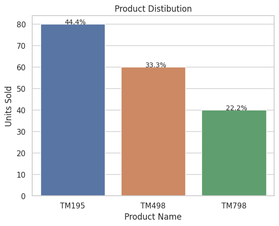

```python
# show the Product distibution
my_countplot(cardio, 'Product', 'Product Name', 'Units Sold', 'Product Distibution')
```

**Observations:**

We see that there are 3 types of Products with TM195 being most popular followed by TM498 then TM798.

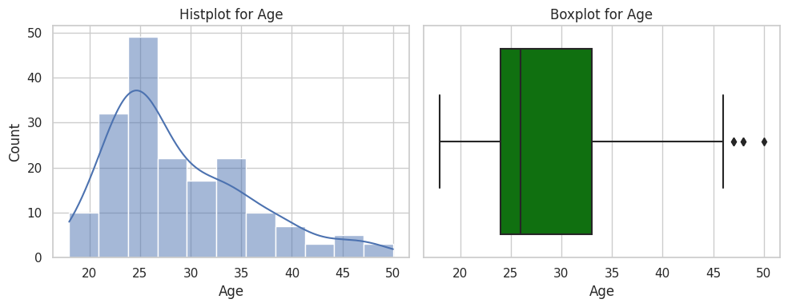

```python
# show the Age distibution
histbox(cardio,"Age")
```

**Observation:**

This histogram shows the right skewed distriubtion of Age.

The majority of customers are under 40 with the largest segment between about 21 and 27 years old.

Outliers begin at 46 and go up to 50.**

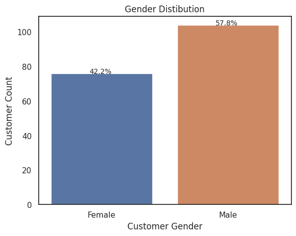

```python
# plot the Gender variable using a countplot
my_countplot(cardio,"Gender", 'Customer Gender', 'Customer Count', 'Gender Distibution')
```

**Observations:**

Males make up nearly 58% of customers.

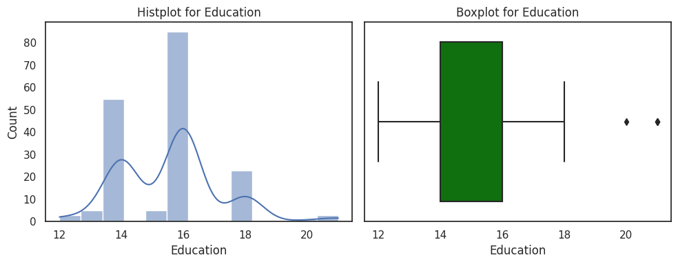

```python
# Show Education distribution using histbox function
histbox(cardio,"Education")
```

**Obeservations:**

Customer's education level falls mainly into grade levels 14 and 16 with some outliers at 20 and above. Data is right skewed.

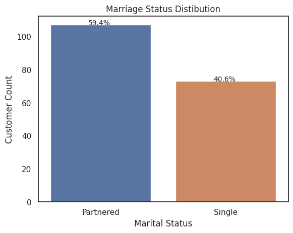

```python
# Show Marital Status distribution using countplot
my_countplot(cardio,"MaritalStatus", 'Marital Status', 'Customer Count', 'Marriage Status Distibution')
```

**Observations:**

The majority (59.4%) of customers are in a relationship with a partner.

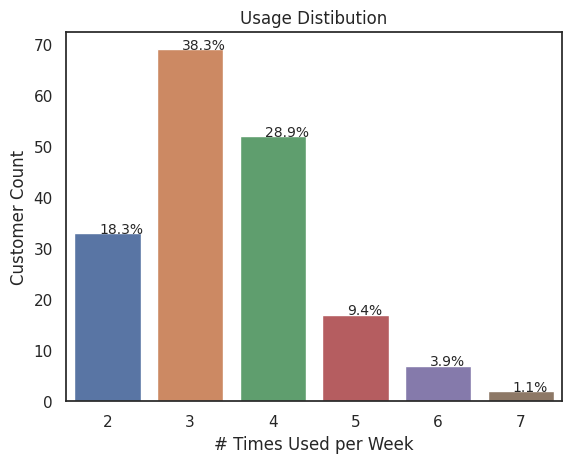

```python
# Plot the Usage varible as a countplot showing Days of Week used
my_countplot(cardio,"Usage", '# Times Used per Week', 'Customer Count', 'Usage Distibution')
```

**Observations:**

The majority of customers (85.5%) are using the product 2 - 4 times per week.

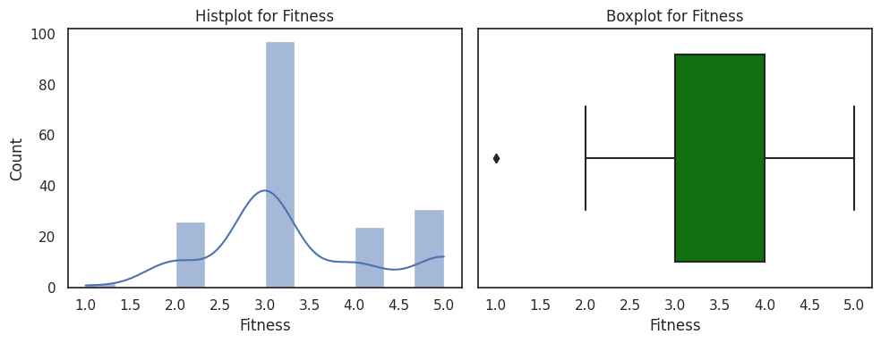

```python
# Show the distribution of Fitness using a histogram
histbox(cardio,"Fitness")
```

**Observations:**

Most customers claim a fitness level of 3. Data is left skewed.

Fitness level 1 is an outlier.

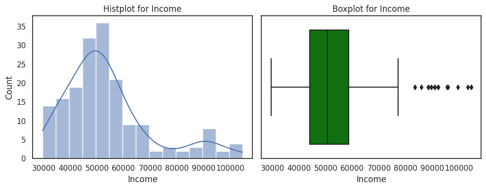

```python
# Show the distribution of Fitness using a histogram
histbox(cardio,"Income")
```

**Observations:**

Most customers earn between 30k -68k.

Data skews to the right.

There are several outliers starting at about 83k.

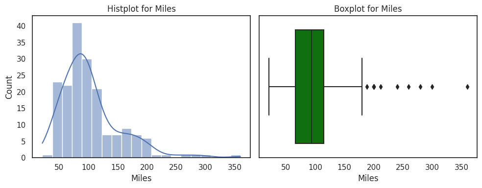

```python
# Show distibution of the Miles Ran each week
histbox(cardio, "Miles")
```

**Observations:**

The sweet spot for the amount of miles ran each week is 30 - 125 miles.

Data skews to the right.

Outliers exist starting 175 and above.

### **Bivariate and Multivariate Analysis**

### **Question 7:** Perform bivariate and multivariate analysis to explore relationships between the important variables in the dataset. (It is a good idea to explore relations between numerical variables as well as relations between numerical and categorical variables) [12 marks]

# Bivariate Analysis Section

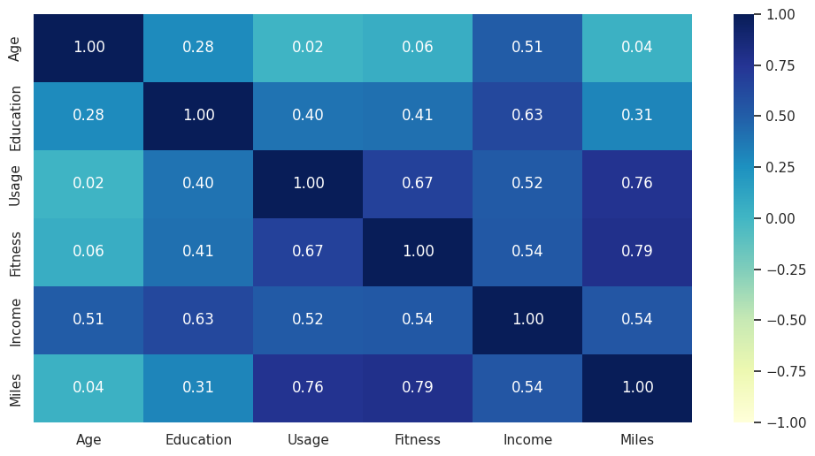

```python
#Start the bivariate analysis by examming numerical variable correlations using a heat map
plt.figure(figsize=(12, 6))
sns.heatmap(cardio.corr(numeric_only=True), vmin=-1, vmax=1, annot=True,  fmt=".2f", cmap="YlGnBu")
plt.show()
```

**Observations:**

There is a high positive correlation between Fitness/Miles and Usage/Miles.

A correlation also exists for Usage/Fitness and Education/Income.

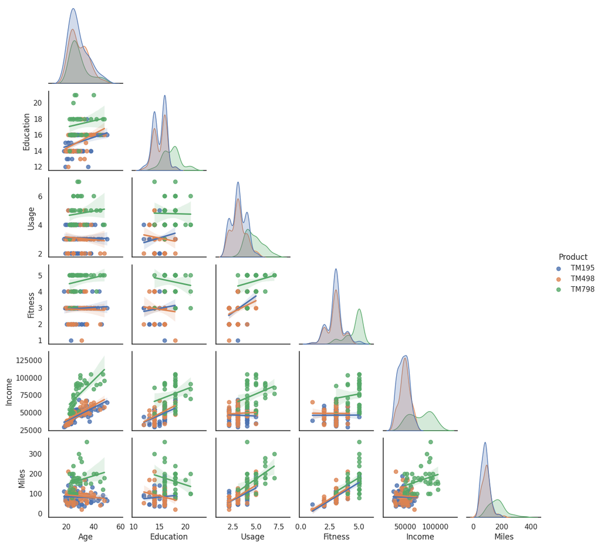

```python
# create a pair plot to evaluate the numerical columns on a single plot
sns.pairplot(data=cardio, hue='Product', kind='reg', diag_kind='kde', height=2, aspect=1, corner=True)
plt.show();
```

**Observations:**

Higher Income customers prefer the TM798 model by a wide margin.

Low to Mid income earners primarily prefer TM195 and TM498 roughly equally.

Higher educated customers prefer TM798 and use it more often at 4+ times per week. Less educated are using the other models 2 -3 times per week.

Power users are mainly buying TM798.

TM798 is mainly purchased by higher earners with incomes over 60K.

The fittest customers own the TM798 while the less fit prefer the TM498 and TM195.

Most customers are clustered between their 20s and 40s and prefer models TM498 and TM195.

### Product vs Gender

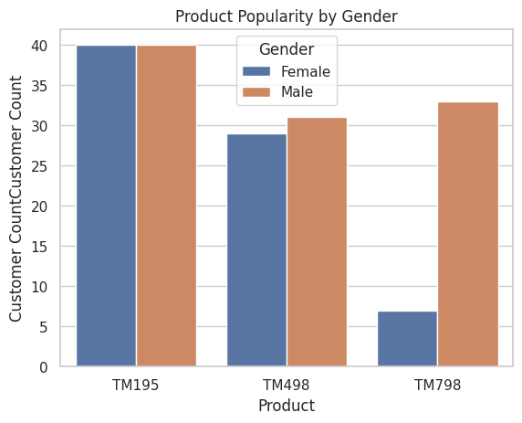

```python
# create a plot of the Product popularity broken down by Gender
sns.set(style="whitegrid") #place a grid on this plot
sns.countplot(x='Product', hue='Gender', data=cardio)
set_labels('Product', 'Customer CountCustomer Count', 'Product Popularity by Gender')
```

**Observations:**

The TM195 is the most popular and is used equally by both genders.

The TM498 is next in popularity and is used slightly more by males.

The TM798 is very popular with males but not with females.

### Product vs Age

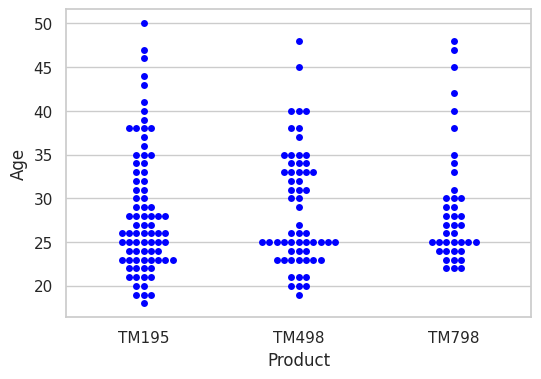

```python
# create a swarm plot to visualize Products across Age
sns.set(style="whitegrid") #place a grid on this plot
plt.figure(figsize=(6,4))
sns.swarmplot(data = cardio, x = cardio["Product"], y = cardio["Age"], color='blue')
plt.show()
```

**Observations:**

Most customers are who are under 40 and use the TM195 product

The age range is fairly consistent across all products.

## Product vs Education

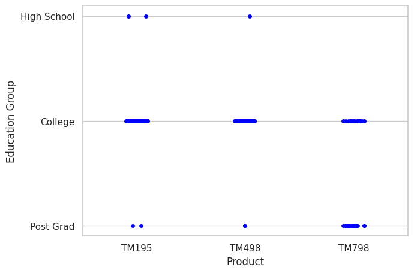

```python
# create a strip plot to visualize Products vs Education
sns.set(style="whitegrid") #place a grid on this plot
plt.figure(figsize=(7,5))
sns.stripplot(data = cardio, x = cardio["Product"], y = cardio["Education Group"], color='blue')
plt.show()
```

**Observations:**

For TM195 and TM498, the customers have mainly college level eduction.

All TM798 customers have college and post grad levels of eduction.

## Product vs Usage

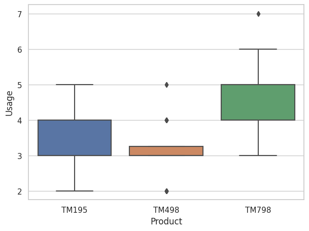

```python
# create a box plot to visualize Products vs Usage
sns.set(style="whitegrid") #place a grid on this plot
plt.figure(figsize=(7,5))
sns.boxplot(data = cardio, x = cardio["Product"], y = cardio["Usage"])
plt.show()
```

**Observations:**

The most used product is the TM798 at 4-5 times per week. The TM195 is used about 3-4 times per week.

The TM498 is used the least but still at about slightly over 3 times per week.

## Product vs Income

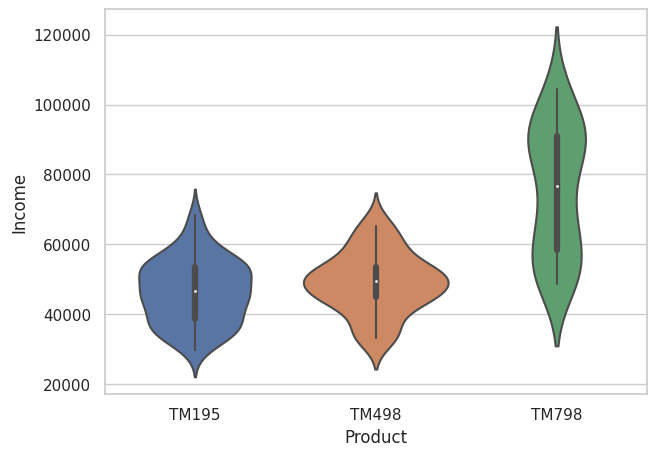

```python
# create a violin plot to visualize Products vs Income
sns.set(style="whitegrid") #place a grid on this plot
plt.figure(figsize=(7,5))
sns.violinplot(data = cardio, x = cardio["Product"], y = cardio["Income"])
plt.show()
```

*Observations:

For products TM195 & TM498 the customers in the 30k - 75K income bracket prefer them almost equally.

High income earners (over 75K) overwhelming prefer TM798.

## Product vs Miles

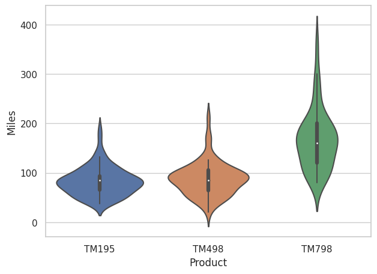

```python
# create a violin plot to visualize Products vs Miles
sns.set(style="whitegrid") #place a grid on this plot
plt.figure(figsize=(7,5))
sns.violinplot(data = cardio, x = cardio["Product"], y = cardio["Miles"])
plt.show()
```

**Observations:**

The amount of miles a customer expects to run is very close between TM195 and TM498.

The higher distance runners prefer the TM798.

## Product vs Fitness

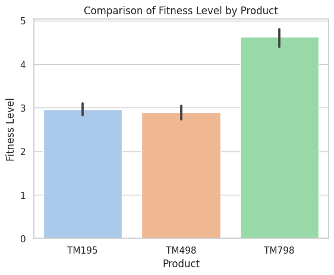

```python
# Using a bar plot to show Product vs Fitness, set labels and show the plot
sns.set(style="whitegrid") #place a grid on this plot
sns.barplot(data=df, x='Product', y='Fitness',palette='pastel')
set_labels('Product', 'Fitness Level', 'Comparison of Fitness Level by Product')
plt.show()
```

**Observations:**

Customers with a high fitness levels prefer TM798.

TM195 & TM498 are both used equally by customers with fitness levels primarily from 1 - 3.

## Product vs Marital Status

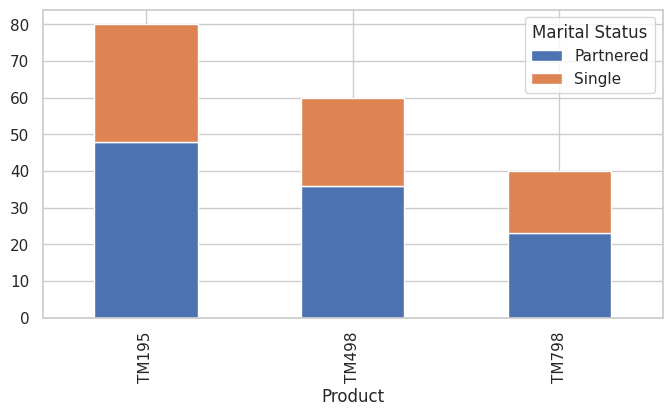

```python
# showing Product vs Marital Status using stacked bar plot
sns.set(style="whitegrid")  # Set the style of the plot

# Group the data by 'Product' and 'MaritalStatus' and calculate the counts
counts = cardio.groupby(['Product', 'MaritalStatus']).size().unstack()

# Create a stacked bar plot
counts.plot(kind='bar', stacked=True, figsize=(8, 4))

# Display the plot
plt.legend(title="Marital Status")
plt.show()
sns.set(style="white")
```

**Observations:**

Each category of product has roughly the same ratio of partnered and single customers.

### **Multivariate Analysis**

This will help us to understand and cater needs of customers better based on their gender,marital status, Age etc.

## Usage vs Gender vs Marital Status

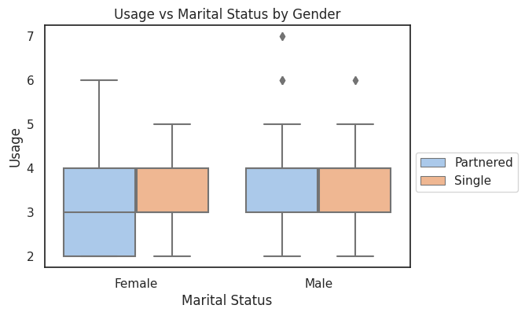

```python
# Use a boxplot to show relationship between Usage, Gender & Marital Status
plt.figure(figsize=(6,4)) #set the plot area size to be readable but not to large
sns.boxplot(data = cardio, x = "Gender", y = "Usage",hue="MaritalStatus",palette="pastel")
plt.legend(bbox_to_anchor=(1.00, .5)) #place legend in desired location
set_labels('Marital Status', 'Usage', 'Usage vs Marital Status by Gender') #call our function to set labels
plt.show()
```

**Oberservations:**

Married females tend to use the products less than single females and men in general.

Married men and single men have the same usage pattern when outliers are omitted.

Married women skew towards less usage than single women.

## Gender vs Income

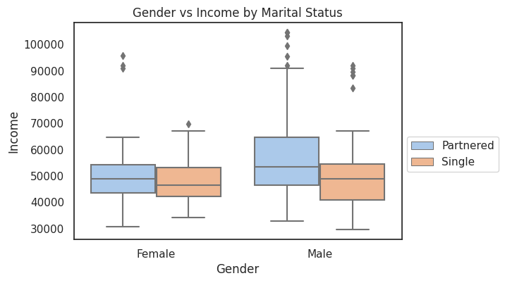

```python
#Boxplot Gender vs Income by Marital Status
plt.figure(figsize=(6,4))
sns.boxplot(data = cardio, x = "Gender", y = "Income",hue=cardio["MaritalStatus"],palette="pastel")
plt.legend(bbox_to_anchor=(1.00, .5)) #place legend in the desired location
set_labels('Gender', 'Income', "Gender vs Income by Marital Status") #call our set label function
plt.show()
```

**Observations:**

Married females earn slightly more than single females.

Married men earn significantly more than single men.

There are outliers in all groups with more seen in men.

[figure not shown]

```python
#Boxplot Gender vs Miles
plt.figure(figsize=(6,4))
sns.boxplot(data = cardio, x = "Gender", y = "Income",palette="pastel")
set_labels('Gender', 'Miles', "Gender vs Miles") #call our set label function
plt.show()
```

**Observations:**

## Gender vs Miles vs Marital Status

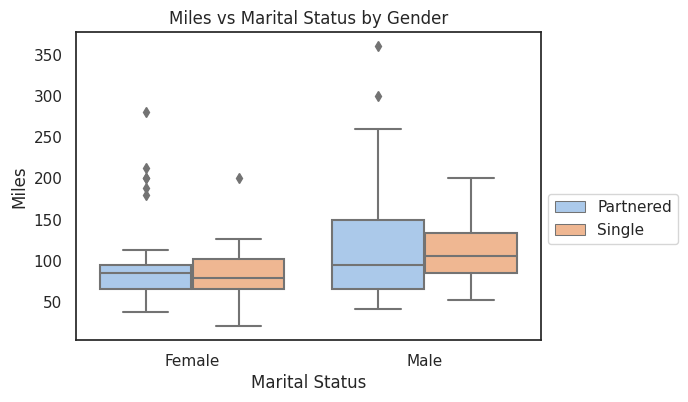

```python
# Use a boxplot to show relationship between Gender, Miles & Marital Status
plt.figure(figsize=(6,4)) #set the plot area size to be readable but not to large
sns.boxplot(data = cardio, x = "Gender", y = "Miles",hue="MaritalStatus",palette="pastel")
plt.legend(bbox_to_anchor=(1.00, .5)) #place legend in desired location
set_labels('Marital Status', 'Miles', 'Miles vs Marital Status by Gender') #call our function to set labels
plt.show()
```

**Observations:**

## Gender vs Miles vs Education

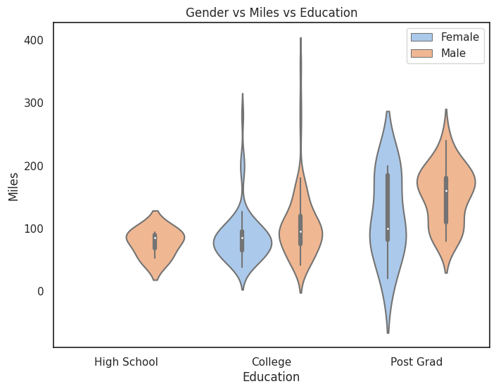

```python
# Use a violin plot to show relationship between Gender, Miles & Marital Status
plt.figure(figsize=(8,6)) #set the plot area size to be readable but not to large
sns.violinplot(data = cardio, x = "Education Group", y = "Miles",hue="Gender",palette="pastel")
plt.legend(bbox_to_anchor=(1.00, 1)) #place legend in desired location
set_labels('Education', 'Miles', 'Gender vs Miles vs Education') #call our function to set labels
plt.show()
```

**Observations:**

The customers that have only a High School education are men.

College educated men and women and high school men run about the same miles. Although men in this group run slightly more miles.

Post Grad men and women are both running more miles than lesser educated customers.

## Age vs Miles vs Gender

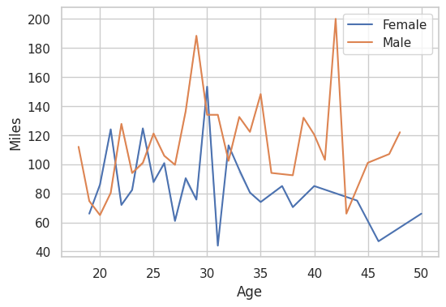

```python
# using a lineplot to show Age vs Miles vs Gender
sns.set(style="whitegrid")  # Set the style of the plot to add a grid
plt.figure(figsize=(6,4)) #set plot area size
sns.lineplot(data = cardio, x = cardio["Age"], y = cardio["Miles"],hue=cardio["Gender"],errorbar=('ci', 0))
plt.legend(bbox_to_anchor=(1.00, 1)) #position the legend
plt.show()
```

**Observations:**

Men and women between 27 and 30 seem to run the most miles.

Women start to run less after 40, some men increase their miles after 40.

## Age vs Miles vs Marital Status

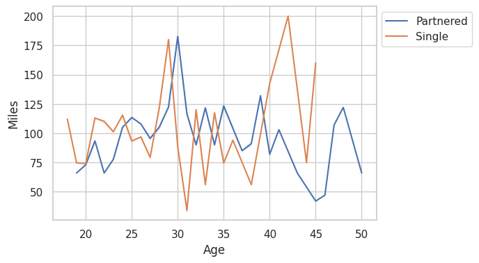

```python
# using a lineplot to show Age vs Miles vs Gender
sns.set(style="whitegrid")  # Add a grid to this plot
plt.figure(figsize=(6,4)) #set plot area size
sns.lineplot(data = cardio, x = cardio["Age"], y = cardio["Miles"],hue=cardio["MaritalStatus"],errorbar=('ci', 0))
plt.legend(bbox_to_anchor=(1.00, 1)) #position the legend
plt.show()
```

**Observations:**

## Age vs Income vs Product

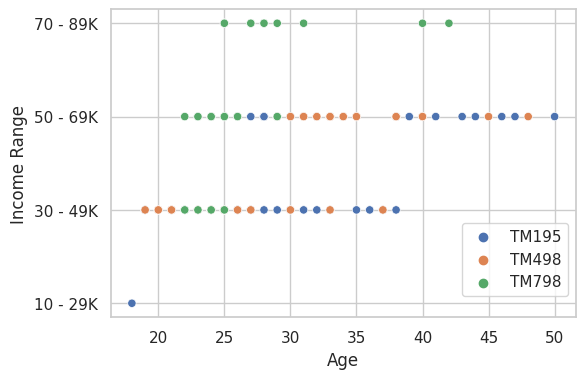

```python
# using a lineplot to show Age vs Miles vs Gender
sns.set(style="whitegrid")  # Add a grid to this plot
plt.figure(figsize=(6,4)) #set plot area size
sns.scatterplot(data = cardio, x = "Age", y = "Income Range",hue= "Product")
plt.gca().invert_yaxis()  # Invert the y-axis to display "Income Range" in descending order
plt.legend(bbox_to_anchor=(1, .33)) #position the legend
plt.show()
```

**Observations:**

The top earners across all age groups are exclusively using the TM798 product.

The Income Range 30 - 69K prefer the TM498 & TM195 roughly the same across age groups.

## Income vs Miles vs Education

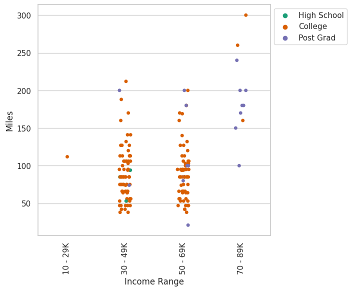

```python
#Use a stripplot to show Income vs Miles vs Education Group
plt.figure(figsize=(6,6)) #set the plot size
sns.stripplot(data = cardio, x  = cardio["Income Range"], y = cardio["Miles"],hue=cardio["Education Group"],palette="Dark2")
plt.xticks(rotation=90) #change th x axis labels to verticle
plt.legend(bbox_to_anchor=(1.00, 1))  #place the legend to the right hand side
plt.show()
```

**Observations:**

Income ranges 30-49K and 50-69K have very similar Miles and Education profiles.

Income levels below $29K have very few customers.

Incomes over 70K are comprised mainly of Post Grad customers who have high Miles.

## Income vs Miles vs Product

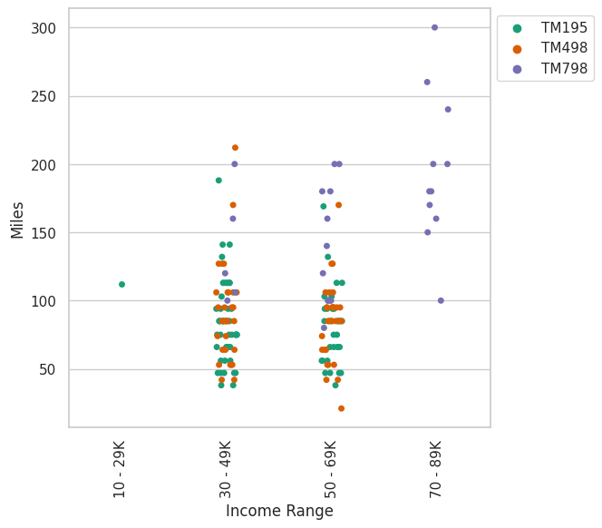

```python
#Use a stripplot to show Income Range vs Miles vs Product
plt.figure(figsize=(6,6)) #set the plot size
sns.stripplot(data = cardio, x  = cardio["Income Range"], y = cardio["Miles"],hue=cardio["Product"],palette="Dark2")
plt.xticks(rotation=90) #change th x axis labels to verticle
plt.legend(bbox_to_anchor=(1.00, 1))  #place the legend to the right hand side
plt.show()
```

**Observations**

The TM798 is used by high earners that run over 150 miles.

Incomes between 30-69K primarily are using the TM195 and TM498 products while running between 50 and 150 miles.

### **Question 8:** Group the data for each product to build customer profiles and summarize the key characteristics of the customers based on the statistical summary. [3 marks]

### Customer Profiles of Product Models

```python
#Data Grouped by TM195 statistical summary
cardio[cardio["Product"]=="TM195"].describe(include='all').T
```

|  | count | unique | top | freq | mean | std | min | 25% | 50% | 75% | max |
| --- | --- | --- | --- | --- | --- | --- | --- | --- | --- | --- | --- |
| Product | 80 | 1 | TM195 | 80 | NaN | NaN | NaN | NaN | NaN | NaN | NaN |
| Age | 80.0 | NaN | NaN | NaN | 28.55 | 7.221452 | 18.0 | 23.0 | 26.0 | 33.0 | 50.0 |
| Gender | 80 | 2 | Female | 40 | NaN | NaN | NaN | NaN | NaN | NaN | NaN |
| Education | 80.0 | NaN | NaN | NaN | 15.0375 | 1.216383 | 12.0 | 14.0 | 16.0 | 16.0 | 18.0 |
| MaritalStatus | 80 | 2 | Partnered | 48 | NaN | NaN | NaN | NaN | NaN | NaN | NaN |
| Usage | 80.0 | NaN | NaN | NaN | 3.0875 | 0.782624 | 2.0 | 3.0 | 3.0 | 4.0 | 5.0 |
| Fitness | 80.0 | NaN | NaN | NaN | 2.9625 | 0.66454 | 1.0 | 3.0 | 3.0 | 3.0 | 5.0 |
| Income | 80.0 | NaN | NaN | NaN | 46418.025 | 9075.78319 | 29562.0 | 38658.0 | 46617.0 | 53439.0 | 68220.0 |
| Miles | 80.0 | NaN | NaN | NaN | 82.7875 | 28.874102 | 38.0 | 66.0 | 85.0 | 94.0 | 188.0 |
| Education Group | 80 | 3 | College | 76 | NaN | NaN | NaN | NaN | NaN | NaN | NaN |
| Income Range | 80 | 3 | 30 - 49K | 47 | NaN | NaN | NaN | NaN | NaN | NaN | NaN |

**Customer Profile for Model TM195:**

Average age of customer who purchases TM195 is 28, Median is 26. Customer age range is between 18 - 50.

Both genders perfer this model equally.

Average Education Level is "some college".

60% of the customers who purchased this model are married.

The customers uses this model an average of 3 times per week.

Self rated average fitness level of customer averages 2.9 out of 5.

Average customer income for ths model is 46K per year.

Customer using this model expect to run 83 miles.

```python
#Data Grouped by TM498 for statistical summary
cardio[cardio["Product"]=="TM498"].describe(include='all').T
```

|  | count | unique | top | freq | mean | std | min | 25% | 50% | 75% | max |
| --- | --- | --- | --- | --- | --- | --- | --- | --- | --- | --- | --- |
| Product | 60 | 1 | TM498 | 60 | NaN | NaN | NaN | NaN | NaN | NaN | NaN |
| Age | 60.0 | NaN | NaN | NaN | 28.9 | 6.645248 | 19.0 | 24.0 | 26.0 | 33.25 | 48.0 |
| Gender | 60 | 2 | Male | 31 | NaN | NaN | NaN | NaN | NaN | NaN | NaN |
| Education | 60.0 | NaN | NaN | NaN | 15.116667 | 1.222552 | 12.0 | 14.0 | 16.0 | 16.0 | 18.0 |
| MaritalStatus | 60 | 2 | Partnered | 36 | NaN | NaN | NaN | NaN | NaN | NaN | NaN |
| Usage | 60.0 | NaN | NaN | NaN | 3.066667 | 0.799717 | 2.0 | 3.0 | 3.0 | 3.25 | 5.0 |
| Fitness | 60.0 | NaN | NaN | NaN | 2.9 | 0.62977 | 1.0 | 3.0 | 3.0 | 3.0 | 4.0 |
| Income | 60.0 | NaN | NaN | NaN | 48973.65 | 8653.989388 | 31836.0 | 44911.5 | 49459.5 | 53439.0 | 67083.0 |
| Miles | 60.0 | NaN | NaN | NaN | 87.933333 | 33.263135 | 21.0 | 64.0 | 85.0 | 106.0 | 212.0 |
| Education Group | 60 | 3 | College | 57 | NaN | NaN | NaN | NaN | NaN | NaN | NaN |
| Income Range | 60 | 2 | 30 - 49K | 30 | NaN | NaN | NaN | NaN | NaN | NaN | NaN |

### Customer Profile for Model TM498:

Average age of customer who purchases TM98 is 29, Median is 26 . Customer age range is between 19 - 48.

The product is used by males and females almost equally.

The average grade level of TM498 customers is at least "some college".

60% of TM498's customers are married.

The customers uses this model an average of 3 times per week.

Self rated average fitness level of customer averages 2.9 out of 5.

Average Income of the customer is 49K.

Customer using this model expect to run 88 miles on average.

```python
#Data Grouped by TM798 for statistical summary
cardio[cardio["Product"]=="TM798"].describe(include="all").T
```

|  | count | unique | top | freq | mean | std | min | 25% | 50% | 75% | max |
| --- | --- | --- | --- | --- | --- | --- | --- | --- | --- | --- | --- |
| Product | 40 | 1 | TM798 | 40 | NaN | NaN | NaN | NaN | NaN | NaN | NaN |
| Age | 40.0 | NaN | NaN | NaN | 29.1 | 6.971738 | 22.0 | 24.75 | 27.0 | 30.25 | 48.0 |
| Gender | 40 | 2 | Male | 33 | NaN | NaN | NaN | NaN | NaN | NaN | NaN |
| Education | 40.0 | NaN | NaN | NaN | 17.325 | 1.639066 | 14.0 | 16.0 | 18.0 | 18.0 | 21.0 |
| MaritalStatus | 40 | 2 | Partnered | 23 | NaN | NaN | NaN | NaN | NaN | NaN | NaN |
| Usage | 40.0 | NaN | NaN | NaN | 4.775 | 0.946993 | 3.0 | 4.0 | 5.0 | 5.0 | 7.0 |
| Fitness | 40.0 | NaN | NaN | NaN | 4.625 | 0.667467 | 3.0 | 4.0 | 5.0 | 5.0 | 5.0 |
| Income | 40.0 | NaN | NaN | NaN | 75441.575 | 18505.83672 | 48556.0 | 58204.75 | 76568.5 | 90886.0 | 104581.0 |
| Miles | 40.0 | NaN | NaN | NaN | 166.9 | 60.066544 | 80.0 | 120.0 | 160.0 | 200.0 | 360.0 |
| Education Group | 40 | 2 | Post Grad | 23 | NaN | NaN | NaN | NaN | NaN | NaN | NaN |
| Income Range | 28 | 3 | 50 - 69K | 12 | NaN | NaN | NaN | NaN | NaN | NaN | NaN |

### Customer Profile for Model TM798:

This Model is the lowest selling model but used my the most affulant and highest educated customers. This implies it is the top end and most expensive model.

83% of customers for this model are men.

The average grade level of TM798 customers is 'Post Grad'.

58% of TM798's customers are married.

The customers uses this model an average of 4.7 times per week.

Self rated average fitness level of customer averages 4.6 out of 5.

Average Income of the customer is 75K.

Customer using this model expect to run 166 mile on average.

### **Summarize of key characteristics of customer base:**

### **Question 9:** Summarize the key characteristics of each product based on the analysis performed. What recommendations would you like to share to help improve the business? [6 marks]

#### **Conclusion & Recommendations for Each Model**

### **Model TM798:**

**Key Characteristics for Model TM798:**

Lowest selling model but used by the most affluent and highest educated customers. Average age of customers 29. 83% of customers are men. Average grade level is Post Grad. 58% of customers are married. Average usage: 4.7 times per week. Average self-rated fitness level: 4.6 out of 5. Average income: $75,000. Customers expect to run an average of 166 miles.

**Recommendations for Model TM798:**

- Capitalize on the high-income and highly educated customer segment by focusing on premium features and high-end marketing strategies.
- Consider expanding marketing efforts targeting women to increase the customer base.
- Enhance the product's exclusivity and premium image to maintain its appeal to affluent customers.
- Offer personalized training programs and advanced features to cater to customers with higher fitness levels.
- Use this model to target neighbor gym franchises such as Anytime Fitness, Snap Fitness and Planet Fitness and try to win large national contracts.

**Key Characteristics for Model TM498:**

This model is the mid-range product in features and price. The average age of customers is 29. It is used almost equal usage by males and females. The average grade level of customers is 'Some College'. 60% of customers are married. Average usage is 3 times per week. Average self-rated fitness level: 2.9 out of 5. Average income: $49,000. Customers expect to run an average of 88 miles.

**Recommendations for Model TM498:**

- Strengthen the mid-range positioning by focusing on features that cater to a broader customer base.
- Invest in marketing campaigns that emphasize the affordability and value-for-money aspects of the product.
- Consider introducing gender-specific marketing strategies to target both male and female customers effectively.
- Offer diverse workout programs and options to accommodate customers with varying fitness levels.

### **Model TM195:**

**Key Characteristics for Model TM195:**

The low end model that delivers on performance but with a budget. Average age of customers is 28. Both genders prefer this model equally. Average education level is Some College. 60% of customers are married. Average usage is 3 times per week. Average self-rated fitness level is 2.9 out of 5. Average income: $46,000. Customers expect to run an average of 83 miles.

**Recommendations for Model TM195:**

- Maintain the product's balanced appeal to both genders by providing features and marketing materials that cater to diverse preferences.
- Emphasize the accessibility and affordability of the product to target a wider customer base.
- Offer customer support and guidance to assist those in the "some college" education level in maximizing the benefits of the product.
- Provide options for customization and personalization to enhance the customer experience.

#### **General Business Recommendations:**

- Conduct market research and hyper target prospects who have a college education, income levels above $50k, are physically fit, and are under between 25 and 50 years old. Especially market the TM798 product to this segment.
- Submit customer surveys to solicit feedback and offer incentives (e.g. Discounts on accessories, future products) for customer referrals.
- Develop targeted marketing campaigns to reach specific customer segments, such as women or individuals with specific fitness goals.
- Develop a campaign targeting budget conscious men and women earning under $45K, with some college, between the ages of 22 - 40 and moderate fittness goals. The TM195 and TM498 products should be marketed to this segment.
- Target national brand gyms to secure national contracts offering volumne pricing and maintainance plans for all 3 products.
- Consider adding a video tablet, WiFi and studio workout streaming capabilites to future products so that an annual fitness subcription can be purchased to create a recurring revenue stream.
- Explore partnerships with social media fitness influencers or experts to endorse the products and attract a broader audience.
- Continuously monitor and analyze customer trends and preferences to stay ahead of the competition and adapt the product offerings accordingly. Provide exceptional customer service and after-sales support to build loyalty and encourage positive word-of-mouth recommendations.